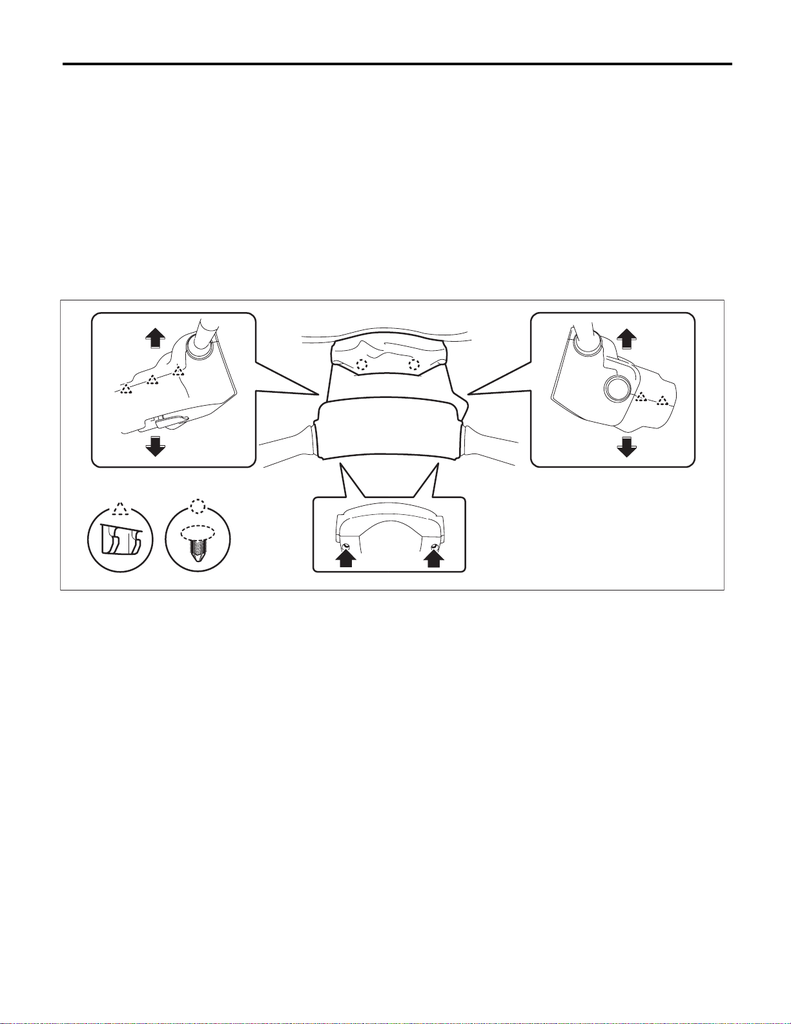

Ignition Switch Illumination

LIGHTING SYSTEM

37.Ignition Switch Illumination

A: REMOVAL

NOTE:

The ignition switch illumination is integrated into the immobilizer antenna assembly.

1) Disconnect the ground cable from battery. <Ref. to NT-5, BATTERY, NOTE, Note.>

NOTE:

For models other than STI model, disconnect the ground terminal from battery sensor.

2) Remove the cover assembly - column.

(1) Remove the screws by turning the steering wheel to right and left.

(2) Release the clips, and remove the cover assembly - steering UPR.

(3) Release the claw, and remove the cover assembly - column UPR and the cover assembly - column

LWR.

[figure not shown]

Ignition Switch Illumination

LIGHTING SYSTEM

3) Remove the ignition switch illumination.

(1) Disconnect the connector.

(2) Release the claw using a flat tip screwdriver or similar tool wrapped with a protection tape, and re-

move the ignition switch illumination.

CAUTION:

Do not apply excessive force to remove the ignition switch illumination lock. Otherwise they may be

broken because those parts are the products made of a plastic.

B: INSTALLATION

1) Install the ignition switch illumination.

2) Install the cover assembly - column.

3) Connect the battery ground terminal. <Ref. to NT-5, BATTERY, NOTE, Note.>

NOTE:

For models other than STI model, connect the ground terminal to battery sensor.

C: INSPECTION

Step Check Yes No

1 CHECK THE IGNITION SWITCH ILLUMINA-

TION.

Make sure the ignition switch illumination illumi-

nates when driver’s side door is open.

Does the ignition switch illumi-

nation illuminate?

Ignition switch illu-

mination is normal.

Go to step 2.

2 CHECK THE IGNITION SWITCH ILLUMINA-

TION.

Make sure the ignition switch illumination blinks

when the ignition switch is turned to ON.

Does the ignition switch illumi-

nation blink?

Check the function

setting of body

integrated unit.

<Ref. to BC(diag)-

2, Basic Diagnostic

Procedure.>

Check the ignition

switch illumination

circuit. <Ref. to SL-

24, CHECK IGNI-

TION SWITCH

ILLUMINATION,

INSPECTION,

Keyless Entry Sys-

tem.>